# MB5370 Module 1 Workshop 4: Intergrating AI

Caitlin Buckle

2026-05-27

Signed up for Github Education and activated co-pilot inside RStudio

### Section 4.3: GitHub Copilot

Practicing prompting copilot to produce code. Use # to make comments, and wait until the code is suggested. Then, press tab to confirm the code

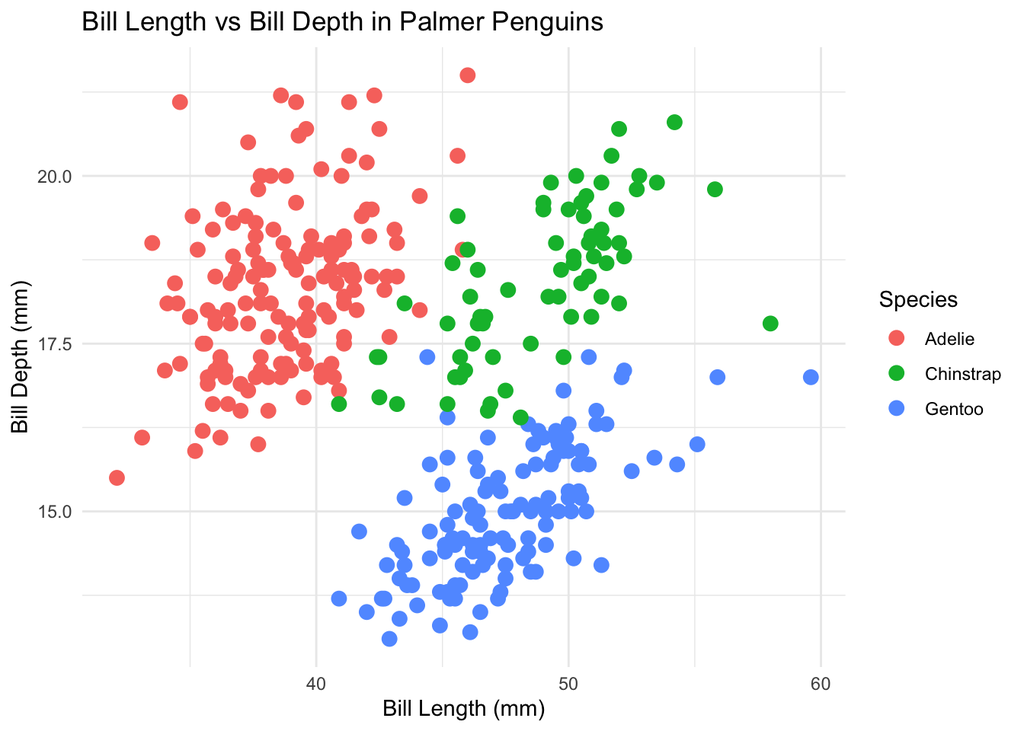

```r
#Load tidyverse and palmerpenguins libraries
library(tidyverse) #code suggested by Copilot
library(palmerpenguins)

#Prompt copilot to create a multivariable scatter plot
#Create a ggplot scatter plot using the palmerpenguins dataset
#Plot bill_len (mm) on x-axis and bill_dep (mm) on the y-axis
#Colour points by species and use geom_point with size = 3
#Add a minimal theme and clean labels
ggplot(data = penguins, aes(x = bill_length_mm, y = bill_depth_mm, color = species)) +
  geom_point(size = 3) +
  theme_minimal() +
  labs(title = "Bill Length vs Bill Depth in Palmer Penguins",
       x = "Bill Length (mm)",
       y = "Bill Depth (mm)",
       color = "Species")
```

#### EXERCISE

Choose one of the options in the workshop and create your own prompts to generate code using Copilot

#### CHOSEN OPTION: Option A (instruct copilot to generate a boxplot comparing flipper_len (mm) across different species, faceted by island, using custom colour palettes)

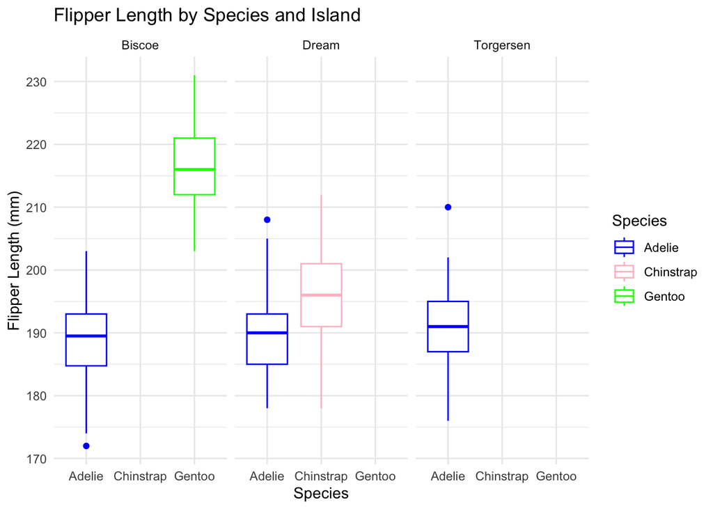

```r
#Create a boxplot using ggplot to compare flipper_len (mm) across different species
#Facet the plot by island, with each island having its own plot
#Colour by species, with adelie being blue, gentoo being green, and chinstrap being pink
#Use a minimal theme
ggplot(data = penguins, aes(x = species, y = flipper_length_mm, color = species)) +
  geom_boxplot() +
  facet_wrap(~ island) +
  scale_color_manual(values = c("Adelie" = "blue", "Gentoo" = "green", "Chinstrap" = "pink")) +
  theme_minimal() +
  labs(title = "Flipper Length by Species and Island",
       x = "Species",
       y = "Flipper Length (mm)",
       color = "Species")
```

```r
#Outcome: copilot generated code correctly created the plot, faceted by island and coloured by species
#To improve, could tidy up the axis labels, create clearer boundaries around the faceted plots to make it easier to read, consider whether a different plot type would better display the data (only adelie penguins are found on every island, chinstrap and gentoo only found on one island each)
```

#### NOTE: Always remember to check the code generated by copilot as it can make mistakes, and try and identify the particular parts of the code that you can change manually rather than relying on copilot to fix the problems.

### Section 4.4: Installing chattr

chattr is fully integrated within RStudio, so can read metadata from your active environment to support contextual support

```r
library(ellmer)
library(chattr)
```

Using Google Gemini AI to connect chattr with LLM

To interact with chattr, use ‘chattr::chattr_app()’ Made into keyboard shortcut –> Ctrl + Shift + O

#### EXAMPLE

Enter this into your chattr, copy the code and execute it. “Show me how to load the built-in iris dataset and use ggplot2 to build a scatter plot of Sepal.Length versus Sepal.Width colored by Species.”

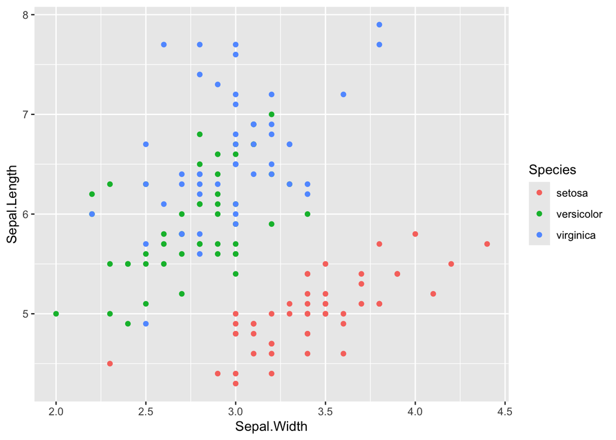

```r
library(ggplot2)
data(iris)
ggplot(data = iris, aes(x = Sepal.Width, y = Sepal.Length, color = Species)) +
  geom_point() #ERROR: running this code causes fatal error, and R session terminates --> updated computer software and R to try and fix the problem
```

```r
#Took 3 hours to fix the problem.... love R
#Fix ended up being to force update 'xfun' package and all associated packages, plus updating computer software and RStudio software
```

### Section 4.3: Conditional Logic

The classic base R conditional structure screens a single value at a time. Its basic anatomy uses round brackets () for the logical condition and curly braces {} for the action if that condition is true.

#### EXAMPLE BELOW

```r
# Simple Example: Checking Sea Surface Temperature (SST)
sst <- 30.2

if (sst > 29.5) {
  print("Warning: Marine heatwave threshold exceeded!")
} else {
  print("SST remains within baseline parameters.")
}
```

```
## [1] "Warning: Marine heatwave threshold exceeded!"
```

```r
#Will give you a warning if described temperature (29.5 in this example) is exceeded. As we set sst at 30.2, we get a warning!
```

Base R if and if-else blocks break down when you pass them an entire column (a vector) of data. They only look at the first item. Because we are already familiar with the tidyverse, we can use vectorised functions that evaluate conditions across complete rows instantly. These functions come from the powerful data-wrangling package dplyr, that comes as part of the tidyverse.

### if_else()

The if_else(condition, true_output, false_output) function evaluates an entire column item-by-item:

#### EXAMPLE BELOW

```r
# Sample coral data
library(tidyverse)
coral_monitoring <- tibble(
  site = c("Site_A", "Site_B", "Site_C"),
  depth_m = c(12, 35, 8)
)

# Classify depth using if_else
coral_monitoring <- coral_monitoring %>%
  mutate(zone = if_else(depth_m > 30, "Deep Reef", "Shallow Reef"))
```

#### QUESTIONS

Answered using information provided by –> ?if_else()

What does mutate do? Allows you to modify/edit data within a data frame, in this example it is modifying the depth column and separating it into deep reef or shallow reef, based on a threshold of 30m

What does &>& do? Called the pipe operator, to ‘pipe’ your results from one operation (coral_monitoring), into the first argument of the next operation (mutate ?). Improves logical flow

### case_when()

When you have more than two possibilities, stacking multiple if-else blocks becomes unreadable. case_when() provides a clean, sequential evaluation layout using formula tildes (~):

```r
coral_monitoring <- coral_monitoring %>%
  mutate(reef_category = case_when(
    depth_m < 10  ~ "Lagoon / Flats",
    depth_m <= 30 ~ "Crest / Slope",
    depth_m > 30  ~ "Mesophotic / Deep",
    TRUE          ~ "Unclassified" # Catch-all remainder
  ))
#We want to stack based on 3 depth possibilities (<10,<=30,>30). Unable to complete with if_else() as can't process multiple blocks, so use case_when instead
```

#### EXERCISE

Using the chattr app or inline copilot, your task here is to write an R script that initialises a tibble named marine_stations containing a column for salinity with values 35, 28, 32, and 12. Use the pipe operator (%>%) and mutate() combined with case_when() to create a new column named environment_type. Classify values below 15 as “Estuarine”, values between 15 and 30 as “Brackish”, and values above 30 as “Marine”. Run your script and verify the table structure.

```r
library(tibble)
marine_stations <- tibble(
  salinity = c(35, 28, 32, 12)
)
marine_stations #creates a tibble with one column (salinty), with one salinity reading in each row
```

```
## # A tibble: 4 × 1
##   salinity
##      <dbl>
## 1       35
## 2       28
## 3       32
## 4       12
```

```r
library(dplyr)
marine_stations <- marine_stations %>%
  mutate(
    environment_type = case_when(
      salinity < 15 ~ "Estuarine",
      salinity >= 15 & salinity <= 30 ~ "Brackish",
      salinity > 30 ~ "Marine"
    )
  )
marine_stations # now tibble has two columns, with the new column using the %>% and mutuate() to classify the salinity readings (in the original column) into the prescribed environment type
```

```
## # A tibble: 4 × 2
##   salinity environment_type
##      <dbl> <chr>
## 1       35 Marine
## 2       28 Brackish
## 3       32 Marine
## 4       12 Estuarine
```

### Section 4.4: Automation - Iterating Efficiency

Automation means instructing R to repeat a task across multiple items without manual copy-pasting. We will cover the foundation (for-loops) and the elegant tidyverse workflow (purrr) side-by-side.

#### Base R: for-loops

A for-loop repeats a code chunk for each element in a designated sequence

```r
# Classic loop anatomy example
for (year in 2020:2024) {
  print(paste("Processing climate data for year:", year))
}
```

```
## [1] "Processing climate data for year: 2020"
## [1] "Processing climate data for year: 2021"
## [1] "Processing climate data for year: 2022"
## [1] "Processing climate data for year: 2023"
## [1] "Processing climate data for year: 2024"
```

If we want to track real-world data, loops can iterate over file directories (e.g., reading 12 monthly turtle tracking CSVs sequentially).

```r
# Loop across index sequences
transect_lengths <- c(50, 100, 25, 75)

for (i in seq_along(transect_lengths)) {
  print(paste("Transect number", i, "measures", transect_lengths[i], "metres."))
} # gives output as "transect number x measures y metres"
```

```
## [1] "Transect number 1 measures 50 metres."
## [1] "Transect number 2 measures 100 metres."
## [1] "Transect number 3 measures 25 metres."
## [1] "Transect number 4 measures 75 metres."
```

#### Tidyverse Alternative: Functional Programming (purrr)

While for-loops are a core programming construct, they require you to manage index variables (i) and explicitly set up empty “containers” to store results, which often leads to verbose code and hidden bugs.

The tidyverse handles iteration via the purrr package using map functions. These map a specific operation onto every item in a list or vector, automatically ensuring that your output matches the precise data structure you expect.

#### COMPARISON EXAMPLE: CALCULATING SQUARE ROOTS OF SITE VECTORS

```r
#Using a standard for-loop
site_areas<-c(144,400,625)
results<-numeric(length(site_areas)) # must build an empty container first
for(i in seq_along(site_areas)) {
  results[i]<-sqrt(site_areas[i])
}
print(results) #output = 12, 20, 25
#Using purrr equivalent

library(purrr)
# Map directly and define your expected output type explicitly
mapped_results <- map_dbl(site_areas, sqrt)
print(mapped_results) #output = 12, 20, 25
```

[output not shown]

There is no right or wrong method, just pick one that works for you and familiarise yourself with the syntax

#### Iterating Across Complex Groups

You can combine purrr pipelines seamlessly inside data frames to split analysis across separate groups:

```r
# Iterate a summary function over split lists of data
data(iris)
iris %>%
  split(.$Species) %>%
  map(~summary(.x))
```

[output not shown]

#### EXERCISE USING CHATTR

Give chattr this prompt. Compare visual simplicity. “I have a list of three vectors containing fish count data. Write a for-loop to calculate the mean of each, and then show me the exact parallel way to do it using purrr’s map_dbl function.”

```r
fish_counts_list <- list(
  c(10, 12, 15, 11),
  c(5, 7, 6, 8, 9),
  c(20, 18, 22)) #Example list of values

# Using a for-loop
mean_counts_for_loop <- numeric(length(fish_counts_list))
for (i in seq_along(fish_counts_list)) {
  mean_counts_for_loop[i] <- mean(fish_counts_list[[i]])
}
mean_counts_for_loop

# Using purrr package
mean_counts_map_dbl <- map_dbl(fish_counts_list, mean)
mean_counts_map_dbl
```

[output not shown]

Personal opinion: purrr and map_dbl() is more visually simple and makes more sense logically for me

### Section 4.5: Writing Custom Functions

A function consists of a Name, Arguments (the input variables), and a Body (the execution logic wrapped inside curly braces).

```r
#Function definition
calculate_coral_mortality<- function(initial_count,surviving_count){
#Logic safety switch using our conditional tools! Initial count must be greater than zero (can't have negative coral colonies...), so using if() to provide a stop message if initial count is less than or equal to zero.
  if(initial_count<=0){
    stop("Initial count must be greater than zero.")
  }
  mortality_rate<-(initial_count-surviving_count)/initial_count #turning initial count and surviving count into a mortality proportion (0-1).
  return(mortality_rate)
}
#Utilising your custom function
calculate_coral_mortality(initial_count=120,surviving_count=84) #defined the two necessary argument (initial_count and surviving_count), then used calculate_coral_mortality() function we created above!
```

```
## [1] 0.3
```

#### BEST PRACTICE:

Always test your custom functions in a clean local environment to ensure they rely strictly on the arguments passed directly into them, rather than accidentally grabbing random background objects floating in your global R environment.

#### EXERCISE

Build a custom function named convert_temp_c_to_f that accepts a single argument representing temperature in Celsius. The function should perform the math conversion: F = (C * 9/5) + 32. Include a conditional safety check using an if statement that halts execution via stop() if the entered value is below absolute zero (-273.15 degrees Celsius). Test your function with both a valid temperature and an invalid value to ensure the error handling behaves as expected.

```r
convert_temp_c_to_f<-
  function(temp_c){
    if(temp_c<=-273.15){
      stop("Temp_c must be greater than absolute zero (-273.15 degrees Celcius)")
    }
  temp_f<-temp_c*(9/5)+32
  return(temp_f)
  }
convert_temp_c_to_f(temp_c=33) #91.4 degrees Farenheit - CORRECT!!
```

```
## [1] 91.4
```

```r
# convert_temp_c_to_f(temp_c=-293.1) --> ERROR: temp_c must be greater than absolute zero (which is what I coded!)
```